# News Classification [Source to this project](https://github.com/sanjeet12/Machine-Learning/tree/master/News%20Classification)

```python
from IPython.display import Image
Image(url='head.jpg')
```

[figure not shown]

**Aim**  
In this project I will build a model in python to identify the category a news based on its headline and little description. The dataset that i am using for this project is "News_Category_Dataset" available here. This is a supervised type of Machine Learning where we have labelled datasset. Here 'category' is the label of the dataset.

**Dataset Decriptions:**

```
1. No of records = 124989
2. No of attributes = 6 i.e. ['authors', 'category', 'date', 'headline', 'link', 'short_description']
3. Label of the dataset = 'category'
4. No of unique category or class = 30 (After combining THE WORDPOST and WORLDPOST categories together)
```

**Algorithms and Results**

[output not shown]

### Content

1. Loading the dataset
2. Analyzing the dataset
3. Feature Engineering
4. Building Model and Evaluation
   1. Linear Support Vector Classification
   2. Artificial Neural Network
   3. Random Forest

#### 1. Loading the Dataset

```python
#import the required libraries
import pandas as pd
import matplotlib.pyplot as plt
import seaborn as sns
from nltk.corpus import stopwords
import nltk
from nltk.tokenize import word_tokenize,sent_tokenize
import keras
import numpy as np
```

```python
data = pd.read_json("News_Category_Dataset.json", lines=True)
```

```python
data.head()
```

|  | authors | category | date | headline | link | short_description |
| --- | --- | --- | --- | --- | --- | --- |
| 0 | Melissa Jeltsen | CRIME | 2018-05-26 | There Were 2 Mass Shootings In Texas Last Week... | https://www.huffingtonpost.com/entry/texas-ama... | She left her husband. He killed their children... |
| 1 | Andy McDonald | ENTERTAINMENT | 2018-05-26 | Will Smith Joins Diplo And Nicky Jam For The 2... | https://www.huffingtonpost.com/entry/will-smit... | Of course it has a song. |
| 2 | Ron Dicker | ENTERTAINMENT | 2018-05-26 | Hugh Grant Marries For The First Time At Age 57 | https://www.huffingtonpost.com/entry/hugh-gran... | The actor and his longtime girlfriend Anna Ebe... |
| 3 | Ron Dicker | ENTERTAINMENT | 2018-05-26 | Jim Carrey Blasts 'Castrato' Adam Schiff And D... | https://www.huffingtonpost.com/entry/jim-carre... | The actor gives Dems an ass-kicking for not fi... |
| 4 | Ron Dicker | ENTERTAINMENT | 2018-05-26 | Julianna Margulies Uses Donald Trump Poop Bags... | https://www.huffingtonpost.com/entry/julianna-... | The "Dietland" actress said using the bags is ... |

#### 2. Analyzing the Dataset

```python
data.describe()
```

|  | authors | category | date | headline | link | short_description |
| --- | --- | --- | --- | --- | --- | --- |
| count | 124989 | 124989 | 124989 | 124989 | 124989 | 124989 |
| unique | 19250 | 31 | 1498 | 124560 | 124964 | 103905 |
| top |  | POLITICS | 2017-01-27 00:00:00 | Sunday Roundup | https://www.huffingtonpost.comhttp://www.polit... |  |
| freq | 14151 | 32739 | 100 | 90 | 2 | 19590 |
| first | NaN | NaN | 2014-04-18 00:00:00 | NaN | NaN | NaN |
| last | NaN | NaN | 2018-05-26 00:00:00 | NaN | NaN | NaN |

```python
print("No of Record in Dataset : \n",len(data))
print("Dataset Columns : \n",data.columns)
```

```
No of Record in Dataset :
 124989
Dataset Columns :
 Index(['authors', 'category', 'date', 'headline', 'link', 'short_description'], dtype='object')
```

```python
print("Dataset Columns data type : \n",data.dtypes)
print("Data information : \n",data.info())
```

```
Dataset Columns data type :
 authors                      object
category                     object
date                 datetime64[ns]
headline                     object
link                         object
short_description            object
dtype: object
<class 'pandas.core.frame.DataFrame'>
RangeIndex: 124989 entries, 0 to 124988
Data columns (total 6 columns):
authors              124989 non-null object
category             124989 non-null object
date                 124989 non-null datetime64[ns]
headline             124989 non-null object
link                 124989 non-null object
short_description    124989 non-null object
dtypes: datetime64[ns](1), object(5)
memory usage: 5.7+ MB
Data information :
 None
```

```python
#The number of classes does this dataset have.
print("Number of categories or classes of the news : ",len(data.category.unique()))
print("All the Categories or classes are : \n",data.category.unique())
```

```
Number of categories or classes of the news :  31
All the Categories or classes are :
 ['CRIME' 'ENTERTAINMENT' 'WORLD NEWS' 'IMPACT' 'POLITICS' 'WEIRD NEWS'
 'BLACK VOICES' 'WOMEN' 'COMEDY' 'QUEER VOICES' 'SPORTS' 'BUSINESS'
 'TRAVEL' 'MEDIA' 'TECH' 'RELIGION' 'SCIENCE' 'LATINO VOICES' 'EDUCATION'
 'COLLEGE' 'PARENTS' 'ARTS & CULTURE' 'STYLE' 'GREEN' 'TASTE'
 'HEALTHY LIVING' 'THE WORLDPOST' 'GOOD NEWS' 'WORLDPOST' 'FIFTY' 'ARTS']
```

```
category
ARTS               1509
ARTS & CULTURE     1339
BLACK VOICES       3858
BUSINESS           4254
COLLEGE            1144
COMEDY             3971
CRIME              2893
EDUCATION          1004
ENTERTAINMENT     14257
FIFTY              1401
GOOD NEWS          1398
GREEN              2622
HEALTHY LIVING     6694
IMPACT             2602
LATINO VOICES      1129
MEDIA              2815
PARENTS            3955
POLITICS          32739
QUEER VOICES       4995
RELIGION           2556
SCIENCE            1381
SPORTS             4167
STYLE              2254
TASTE              2096
TECH               1231
THE WORLDPOST      3664
TRAVEL             2145
WEIRD NEWS         2670
WOMEN              3490
WORLD NEWS         2177
WORLDPOST          2579
dtype: int64
```

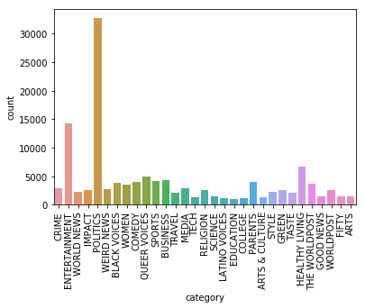

```python
#frequency of each category
sns.countplot(x='category',data = data,orient="V")
print(data.groupby('category').size())
plt.xticks(rotation=90)
plt.show()
```

In the given dataset we can see that the top 3 news categories are Polytics, Entertainment and Healthy Living. And we also noticed that categories 'THE WORLDPOST' and 'WORLDPOST' are same so we will combined those in feature engineering step.

### 3. Feature Engineering

#### Combining the repeated columns

```python
#combining 'THE WORLDPOST' and 'WORLDPOST'
data.category = data.category.map(lambda x:'WORLDPOST' if x=='THE WORLDPOST' else x)
print("Finally total No of categories or classes :",len(data.category.unique()))
```

```
Finally total No of categories or classes : 30
```

#### Combining headline and description

```python
#combine the headline and short description since together it will be used to determine the category of a news.
data['text'] = data.headline + " " + data.short_description
data.head(2)
```

|  | authors | category | date | headline | link | short_description | text |
| --- | --- | --- | --- | --- | --- | --- | --- |
| 0 | Melissa Jeltsen | CRIME | 2018-05-26 | There Were 2 Mass Shootings In Texas Last Week... | https://www.huffingtonpost.com/entry/texas-ama... | She left her husband. He killed their children... | There Were 2 Mass Shootings In Texas Last Week... |
| 1 | Andy McDonald | ENTERTAINMENT | 2018-05-26 | Will Smith Joins Diplo And Nicky Jam For The 2... | https://www.huffingtonpost.com/entry/will-smit... | Of course it has a song. | Will Smith Joins Diplo And Nicky Jam For The 2... |

```python
import re
from nltk.corpus import stopwords
from nltk.stem import SnowballStemmer
stemmer = SnowballStemmer('english')
words = stopwords.words('english')
data['cleaned_text'] = data['text'].apply(lambda x:" ".join([stemmer.stem(i) for i in re.sub("[^a-zA-Z]"," ",x).split() if i not in words]))
```

```python
data.head(2)
```

|  | authors | category | date | headline | link | short_description | text | cleaned_text |
| --- | --- | --- | --- | --- | --- | --- | --- | --- |
| 0 | Melissa Jeltsen | CRIME | 2018-05-26 | There Were 2 Mass Shootings In Texas Last Week... | https://www.huffingtonpost.com/entry/texas-ama... | She left her husband. He killed their children... | There Were 2 Mass Shootings In Texas Last Week... | there were mass shoot in texa last week but on... |
| 1 | Andy McDonald | ENTERTAINMENT | 2018-05-26 | Will Smith Joins Diplo And Nicky Jam For The 2... | https://www.huffingtonpost.com/entry/will-smit... | Of course it has a song. | Will Smith Joins Diplo And Nicky Jam For The 2... | will smith join diplo and nicki jam for the wo... |

#### Encode the text into numerical value

```python
from keras.preprocessing import sequence
from keras.preprocessing.text import Tokenizer, text_to_word_sequence
# tokenizing
tokenizer = Tokenizer()
tokenizer.fit_on_texts(data.cleaned_text)
X = tokenizer.texts_to_sequences(data.cleaned_text)
data['words'] = X

# we will delete some empty and small data
data['word_length'] = data.words.apply(lambda i: len(i))
data = data[data.word_length >= 5]

data.head(2)
```

|  | authors | category | date | headline | link | short_description | text | cleaned_text | words | word_length |
| --- | --- | --- | --- | --- | --- | --- | --- | --- | --- | --- |
| 0 | Melissa Jeltsen | CRIME | 2018-05-26 | There Were 2 Mass Shootings In Texas Last Week... | https://www.huffingtonpost.com/entry/texas-ama... | She left her husband. He killed their children... | There Were 2 Mass Shootings In Texas Last Week... | there were mass shoot in texa last week but on... | [126, 942, 933, 234, 5, 500, 115, 75, 53, 636,... | 22 |
| 1 | Andy McDonald | ENTERTAINMENT | 2018-05-26 | Will Smith Joins Diplo And Nicky Jam For The 2... | https://www.huffingtonpost.com/entry/will-smit... | Of course it has a song. | Will Smith Joins Diplo And Nicky Jam For The 2... | will smith join diplo and nicki jam for the wo... | [77, 1424, 545, 11293, 11, 3660, 4054, 8, 1, 3... | 16 |

we see here that all the news are of different length so there is a need to padding and convert all the news of same length. So that it can be used as input for building the model.

#### Encoding the category into numerical value

```python
# Encode the category to id
categories = data.groupby('category').size().index.tolist()
category_int = {}
int_category = {}
for i, k in enumerate(categories):
    category_int.update({k:i})
    int_category.update({i:k})

data['c2id'] = data['category'].apply(lambda x: category_int[x])
```

```python
data.head(2)
```

|  | authors | category | date | headline | link | short_description | text | cleaned_text | words | word_length | c2id |
| --- | --- | --- | --- | --- | --- | --- | --- | --- | --- | --- | --- |
| 0 | Melissa Jeltsen | CRIME | 2018-05-26 | There Were 2 Mass Shootings In Texas Last Week... | https://www.huffingtonpost.com/entry/texas-ama... | She left her husband. He killed their children... | There Were 2 Mass Shootings In Texas Last Week... | there were mass shoot in texa last week but on... | [126, 942, 933, 234, 5, 500, 115, 75, 53, 636,... | 22 | 6 |
| 1 | Andy McDonald | ENTERTAINMENT | 2018-05-26 | Will Smith Joins Diplo And Nicky Jam For The 2... | https://www.huffingtonpost.com/entry/will-smit... | Of course it has a song. | Will Smith Joins Diplo And Nicky Jam For The 2... | will smith join diplo and nicki jam for the wo... | [77, 1424, 545, 11293, 11, 3660, 4054, 8, 1, 3... | 16 | 8 |

Converting the cleaned text into vector form using tfidf vectorizer and selecting the best 3000 features out of them using chi2.

```python
from sklearn.feature_extraction.text import TfidfVectorizer
tfidf = TfidfVectorizer(sublinear_tf=True, min_df=5, norm='l2', encoding='latin-1', ngram_range=(1, 2), stop_words='english')
features = tfidf.fit_transform(data.cleaned_text)
labels =  tfidf.get_feature_names()

print(features.shape)

from sklearn.feature_selection import SelectKBest
from sklearn.feature_selection import chi2
new_features = SelectKBest(chi2, k=3000).fit_transform(features, data.c2id)

#print(labels)
print(new_features.shape)
```

```
(123673, 50153)
(123673, 3000)
```

### splitting data into train and test set

```python
from sklearn.model_selection import train_test_split
xtrain, xtest, ytrain, ytest = train_test_split(new_features, data.c2id, test_size= 0.2, random_state=42)
```

```python
print("xtrain :",xtrain.shape)
print("ytrain :",ytrain.shape)
print("xtest :",xtest.shape)
print("ytest :",ytest.shape)
```

```
xtrain : (98938, 3000)
ytrain : (98938,)
xtest : (24735, 3000)
ytest : (24735,)
```

## 4. Building Model on the above preprocessed dataset

### A. Linear Support Vector Classification

```python
#import the required libraries
from sklearn.model_selection import train_test_split
from sklearn.svm import LinearSVC
from sklearn.pipeline import Pipeline
from sklearn.feature_selection import SelectKBest,chi2
from sklearn.feature_extraction.text import TfidfVectorizer
```

```python
#split the dataset into train and test sets
x_train,x_test,y_train,y_test = train_test_split(data['cleaned_text'],data.c2id,test_size=0.2)
```

```python
#create a pipeline for implementing Linear Support Vector Classification
pipeline = Pipeline([('vect',TfidfVectorizer(ngram_range=(1,2),stop_words='english',sublinear_tf=True)),
                    ('chi',SelectKBest(chi2,k=1000)),
                    ('clf',LinearSVC(C=1.0,penalty='l1',max_iter=3000,dual=False))])
```

```python
#fit the model
model = pipeline.fit(x_train,y_train)
```

```python
vectorizer = model.named_steps['vect']
chi = model.named_steps['chi']
clf = model.named_steps['clf']
```

```python
#get the feature names
feature_names = vectorizer.get_feature_names()
feature_names = [feature_names[i] for i in chi.get_support(indices=True)]
feature_names = np.asarray(feature_names)
print(feature_names.shape)
```

```
(1000,)
```

```python
#test the accuracy of the model
print("Accuracy Score : " + str(model.score(x_test,y_test)))
```

```
Accuracy Score : 0.5431574691732363
```

```python
#evaluation on test data and show the confusion matrix
pred = model.predict(x_test)
from sklearn.metrics import confusion_matrix, accuracy_score
print("Confusion matrix \n",confusion_matrix(pred, y_test))
```

```
Confusion matrix
 [[ 141   64    4    6    0    3    0    1   19    1    3    6    7    3
     3    1    2   13    2    2    0    1    3    1    0    4    5    1
     4    3]
 [  14   27    5    1    2    2    0    0   13    1    2    1    5    2
     1    1    2   17    3    0    0    1    1    0    0    3    2    5
     0    5]
 [   3    3  198    4    2    5   10    4   38    1    2    0    3    3
     4    1    5   67    8    3    3    6    3    1    4    1    1    6
     1    2]
 [   6    5    6  317    4    4    8    4   27    7    9   10   29   29
     1   22    9   63    2    1    1    4    8    5   31   11   15   22
     4   12]
 [   0    0   11    6  119    7    2   17    6    2    2    3    8    9
     4    2    3   29    2    0    0    1    0    2    0    2    4   13
     2    2]
 [   0    0    2    0    0  262    0    1   65    0    0    1    0    1
     1    8    5   17    4    2    0    2    2    1    0    0    2    5
     1    0]
 [   0    1   42    5    6    3  315    1   40    0   11    5    3    3
     2    4    4   73    2    6    1   10    0    0    1    0   54   12
    11   22]
 [   0    0    3    2    7    2    3   64    4    0    3    0    5   13
     1    0   13   31    1    2    0    0    1    0    1    0    0    2
     3    0]
 [  63   45  160   33   10  122   24    4 1539   21   32   24   69   25
    26   37   58   85   81   16   19   63   68   16   20   15   68   93
     9   24]
 [   1    0    1    5    0    2    1    0    9   71    1    2    8    3
     0    0    9   12    0    2    1    0    2    0    0    1    1    6
     1    0]
 [   0    0    0    0    0    3    2    0    4    0   20   17    0    0
     0    0    0    0    1    0    0    2    0    0    0    1    7    1
     0    0]
 [   4    0    3   20    1    8   10    0   12    2   27  198   13   16
     1    5    1   57    0    3   16    4    1    5    3   11   23    1
    10   23]
 [  11    9   15   62    9   20    9   10   66   57   35   17  669   66
     5   10   42  100   17   19   44   17   34   24    7   16   20   69
     3   22]
```

[output cut: 36 more lines]

```
 [   1    4    5   10    0    8    5    0   22    7    1   12   14    5
     1    1    5   24    7    5    2    4    5    4    2  205   11    3
     3   15]
 [   1    2    0    1    0   11    6    0    8    0   13    5    2    3
     0    2    1    7    2    1    5    2    3    2    1    0   42    1
     0    4]
 [   6   13    9   18    2    5   10    2   38    8    2    0   18   18
     4    3   10   46    6    3    3    5    7    2    3    2   12  214
     3   13]
 [   1    0    1    0    0    0    0    0    3    0    0    1    0    0
     0    1    1    6    0    1    0    0    0    0    0    4    1    0
    43   28]
 [   9    4    2   13    4    6   20    3   19    4    1   24   12   25
     2   13    1  172    3   17    3   11    4    2    7   11   11    6
   177  615]]
```

-------End Linear Support Vector Classification---------------------

### B. Artifical Neural Network

```python
# Importing the required libraries
import keras
from keras.models import Sequential
from keras.layers import Dense
from sklearn.model_selection import train_test_split
```

```python
#split the data into train and test splits
from sklearn.model_selection import train_test_split
xtrain, xtest, ytrain, ytest = train_test_split(new_features, data.c2id, test_size= 0.3, random_state=42)
```

```python
#initializing out squential network based artificial neural network
model = Sequential()
#first hidden layer with 2000 neurons in it
model.add(Dense(output_dim = 2000, init = 'uniform', activation = 'relu', input_dim = 3000))
#second hiddent layer with 500 neurons in it
model.add(Dense(output_dim = 500, init = 'uniform', activation = 'relu'))
#third hiddent layer with 100 neurons in it
model.add(Dense(output_dim = 100, init = 'uniform', activation = 'relu'))
# final output layer with 30 neuron
model.add(Dense(output_dim = 30
                , init = 'uniform', activation = 'sigmoid'))


#compiling teh model using loss as binary_crossentropy , optimizer as adam
model.compile(optimizer = 'adam', loss = 'sparse_categorical_crossentropy', metrics = ['accuracy'])

#fit the model with our training dataset
model.fit(xtrain, ytrain, batch_size = 20, nb_epoch = 5)

#now it's time to make prediction on our X_test data set
predict_y = model.predict(xtest)
```

[output not shown]

### Random Forest Classifier

```python
from sklearn.model_selection import train_test_split
from sklearn.ensemble import RandomForestClassifier
#Import scikit-learn metrics module for accuracy calculation
from sklearn import metrics

#splitting the data into train set and test set - 70% train and 30% test
X_train, X_test, y_train, y_test = train_test_split(new_features, data.c2id, test_size=0.3)

#Create a Gaussian Classifier
rfmodel=RandomForestClassifier(n_estimators=100)

#train the model
rfmodel.fit(X_train,y_train)

#predicting on test dataset
rf_y_pred=rfmodel.predict(X_test)

print("Accuracy:",metrics.accuracy_score(y_test, rf_y_pred))
```

```
Accuracy: 0.5353080696458412
```

### Sanjeet Kumar

sanjeetiiitd@gmil.com